# Risk Factor Analysis

## Outcome Variable

**Outcome Variable:** stunted

## Predictor Variables

**Intervention Variable:** hdlvry

**Adjustment Set:**

unadjusted

## Stratifying Variables

The analysis was stratified on these variable(s):

- agecat
- studyid
- country

## Data Summary

| agecat | studyid | country | A | n | nA | nAY0 | nAY1 |
| --- | --- | --- | --- | --- | --- | --- | --- |
| Birth | ki1000108-CMC-V-BCS-2002 | INDIA | 0 | 90 | 90 | 74 | 16 |
| Birth | ki1000108-CMC-V-BCS-2002 | INDIA | 1 | 90 | 0 | 0 | 0 |
| Birth | ki1000108-IRC | INDIA | 0 | 388 | 381 | 337 | 44 |
| Birth | ki1000108-IRC | INDIA | 1 | 388 | 7 | 6 | 1 |
| Birth | ki1000109-EE | PAKISTAN | 0 | 2 | 2 | 1 | 1 |
| Birth | ki1000109-EE | PAKISTAN | 1 | 2 | 0 | 0 | 0 |
| Birth | ki1000304b-SAS-CompFeed | INDIA | 0 | 67 | 8 | 4 | 4 |
| Birth | ki1000304b-SAS-CompFeed | INDIA | 1 | 67 | 59 | 46 | 13 |
| Birth | ki1017093c-NIH-Crypto | BANGLADESH | 0 | 27 | 22 | 18 | 4 |
| Birth | ki1017093c-NIH-Crypto | BANGLADESH | 1 | 27 | 5 | 4 | 1 |
| Birth | ki1135781-COHORTS | INDIA | 0 | 4694 | 2938 | 2613 | 325 |
| Birth | ki1135781-COHORTS | INDIA | 1 | 4694 | 1756 | 1534 | 222 |
| Birth | kiGH5241-JiVitA-3 | BANGLADESH | 0 | 142 | 4 | 2 | 2 |
| Birth | kiGH5241-JiVitA-3 | BANGLADESH | 1 | 142 | 138 | 108 | 30 |
| Birth | kiGH5241-JiVitA-4 | BANGLADESH | 0 | 223 | 10 | 9 | 1 |
| Birth | kiGH5241-JiVitA-4 | BANGLADESH | 1 | 223 | 213 | 146 | 67 |
| 3 months | ki1000108-CMC-V-BCS-2002 | INDIA | 0 | 359 | 352 | 263 | 89 |
| 3 months | ki1000108-CMC-V-BCS-2002 | INDIA | 1 | 359 | 7 | 7 | 0 |
| 3 months | ki1000108-IRC | INDIA | 0 | 407 | 399 | 310 | 89 |
| 3 months | ki1000108-IRC | INDIA | 1 | 407 | 8 | 6 | 2 |
| 3 months | ki1000109-EE | PAKISTAN | 0 | 374 | 252 | 110 | 142 |
| 3 months | ki1000109-EE | PAKISTAN | 1 | 374 | 122 | 48 | 74 |
| 3 months | ki1000304b-SAS-CompFeed | INDIA | 0 | 359 | 71 | 55 | 16 |
| 3 months | ki1000304b-SAS-CompFeed | INDIA | 1 | 359 | 288 | 209 | 79 |
| 3 months | ki1000304b-SAS-FoodSuppl | INDIA | 0 | 97 | 24 | 18 | 6 |
| 3 months | ki1000304b-SAS-FoodSuppl | INDIA | 1 | 97 | 73 | 41 | 32 |
| 3 months | ki1017093b-PROVIDE | BANGLADESH | 0 | 645 | 482 | 431 | 51 |
| 3 months | ki1017093b-PROVIDE | BANGLADESH | 1 | 645 | 163 | 136 | 27 |
| 3 months | ki1017093c-NIH-Crypto | BANGLADESH | 0 | 728 | 565 | 448 | 117 |
| 3 months | ki1017093c-NIH-Crypto | BANGLADESH | 1 | 728 | 163 | 124 | 39 |

[output cut: 118 more lines]

The following strata were considered:

- agecat: 12 months, studyid: ki1000108-CMC-V-BCS-2002, country: INDIA
- agecat: 12 months, studyid: ki1000108-IRC, country: INDIA
- agecat: 12 months, studyid: ki1000109-EE, country: PAKISTAN
- agecat: 12 months, studyid: ki1000304b-SAS-CompFeed, country: INDIA
- agecat: 12 months, studyid: ki1000304b-SAS-FoodSuppl, country: INDIA
- agecat: 12 months, studyid: ki1017093b-PROVIDE, country: BANGLADESH
- agecat: 12 months, studyid: ki1017093c-NIH-Crypto, country: BANGLADESH
- agecat: 12 months, studyid: ki1066203-TanzaniaChild2, country: TANZANIA, UNITED REPUBLIC OF
- agecat: 12 months, studyid: ki1113344-GMS-Nepal, country: NEPAL
- agecat: 12 months, studyid: ki1135781-COHORTS, country: INDIA
- agecat: 12 months, studyid: kiGH5241-JiVitA-3, country: BANGLADESH
- agecat: 12 months, studyid: kiGH5241-JiVitA-4, country: BANGLADESH
- agecat: 18 months, studyid: ki1000108-CMC-V-BCS-2002, country: INDIA
- agecat: 18 months, studyid: ki1000108-IRC, country: INDIA
- agecat: 18 months, studyid: ki1000109-EE, country: PAKISTAN
- agecat: 18 months, studyid: ki1000304b-SAS-CompFeed, country: INDIA
- agecat: 18 months, studyid: ki1000304b-SAS-FoodSuppl, country: INDIA
- agecat: 18 months, studyid: ki1017093b-PROVIDE, country: BANGLADESH
- agecat: 18 months, studyid: ki1017093c-NIH-Crypto, country: BANGLADESH
- agecat: 18 months, studyid: ki1066203-TanzaniaChild2, country: TANZANIA, UNITED REPUBLIC OF
- agecat: 18 months, studyid: ki1113344-GMS-Nepal, country: NEPAL
- agecat: 18 months, studyid: kiGH5241-JiVitA-4, country: BANGLADESH
- agecat: 24 months, studyid: ki1000108-CMC-V-BCS-2002, country: INDIA
- agecat: 24 months, studyid: ki1000108-IRC, country: INDIA
- agecat: 24 months, studyid: ki1017093b-PROVIDE, country: BANGLADESH
- agecat: 24 months, studyid: ki1017093c-NIH-Crypto, country: BANGLADESH
- agecat: 24 months, studyid: ki1066203-TanzaniaChild2, country: TANZANIA, UNITED REPUBLIC OF
- agecat: 24 months, studyid: ki1113344-GMS-Nepal, country: NEPAL
- agecat: 24 months, studyid: ki1135781-COHORTS, country: INDIA
- agecat: 24 months, studyid: kiGH5241-JiVitA-3, country: BANGLADESH
- agecat: 24 months, studyid: kiGH5241-JiVitA-4, country: BANGLADESH
- agecat: 3 months, studyid: ki1000108-CMC-V-BCS-2002, country: INDIA
- agecat: 3 months, studyid: ki1000108-IRC, country: INDIA
- agecat: 3 months, studyid: ki1000109-EE, country: PAKISTAN
- agecat: 3 months, studyid: ki1000304b-SAS-CompFeed, country: INDIA
- agecat: 3 months, studyid: ki1000304b-SAS-FoodSuppl, country: INDIA
- agecat: 3 months, studyid: ki1017093b-PROVIDE, country: BANGLADESH
- agecat: 3 months, studyid: ki1017093c-NIH-Crypto, country: BANGLADESH
- agecat: 3 months, studyid: ki1066203-TanzaniaChild2, country: TANZANIA, UNITED REPUBLIC OF
- agecat: 3 months, studyid: ki1113344-GMS-Nepal, country: NEPAL
- agecat: 3 months, studyid: ki1135781-COHORTS, country: INDIA
- agecat: 3 months, studyid: kiGH5241-JiVitA-3, country: BANGLADESH
- agecat: 3 months, studyid: kiGH5241-JiVitA-4, country: BANGLADESH
- agecat: 6 months, studyid: ki1000108-CMC-V-BCS-2002, country: INDIA
- agecat: 6 months, studyid: ki1000108-IRC, country: INDIA
- agecat: 6 months, studyid: ki1000109-EE, country: PAKISTAN
- agecat: 6 months, studyid: ki1000304b-SAS-CompFeed, country: INDIA
- agecat: 6 months, studyid: ki1000304b-SAS-FoodSuppl, country: INDIA
- agecat: 6 months, studyid: ki1017093b-PROVIDE, country: BANGLADESH
- agecat: 6 months, studyid: ki1017093c-NIH-Crypto, country: BANGLADESH
- agecat: 6 months, studyid: ki1066203-TanzaniaChild2, country: TANZANIA, UNITED REPUBLIC OF
- agecat: 6 months, studyid: ki1113344-GMS-Nepal, country: NEPAL
- agecat: 6 months, studyid: ki1135781-COHORTS, country: INDIA
- agecat: 6 months, studyid: kiGH5241-JiVitA-3, country: BANGLADESH
- agecat: 6 months, studyid: kiGH5241-JiVitA-4, country: BANGLADESH
- agecat: 9 months, studyid: ki1000108-CMC-V-BCS-2002, country: INDIA
- agecat: 9 months, studyid: ki1000108-IRC, country: INDIA
- agecat: 9 months, studyid: ki1000109-EE, country: PAKISTAN
- agecat: 9 months, studyid: ki1000304b-SAS-CompFeed, country: INDIA
- agecat: 9 months, studyid: ki1000304b-SAS-FoodSuppl, country: INDIA
- agecat: 9 months, studyid: ki1017093b-PROVIDE, country: BANGLADESH
- agecat: 9 months, studyid: ki1017093c-NIH-Crypto, country: BANGLADESH
- agecat: 9 months, studyid: ki1066203-TanzaniaChild2, country: TANZANIA, UNITED REPUBLIC OF
- agecat: 9 months, studyid: ki1113344-GMS-Nepal, country: NEPAL
- agecat: 9 months, studyid: ki1135781-COHORTS, country: INDIA
- agecat: 9 months, studyid: kiGH5241-JiVitA-4, country: BANGLADESH
- agecat: Birth, studyid: ki1000108-CMC-V-BCS-2002, country: INDIA
- agecat: Birth, studyid: ki1000108-IRC, country: INDIA
- agecat: Birth, studyid: ki1000109-EE, country: PAKISTAN
- agecat: Birth, studyid: ki1000304b-SAS-CompFeed, country: INDIA
- agecat: Birth, studyid: ki1017093c-NIH-Crypto, country: BANGLADESH
- agecat: Birth, studyid: ki1135781-COHORTS, country: INDIA
- agecat: Birth, studyid: kiGH5241-JiVitA-3, country: BANGLADESH
- agecat: Birth, studyid: kiGH5241-JiVitA-4, country: BANGLADESH

### Dropped Strata

Some strata were dropped due to rare outcomes:

- agecat: Birth, studyid: ki1000108-CMC-V-BCS-2002, country: INDIA
- agecat: Birth, studyid: ki1000108-IRC, country: INDIA
- agecat: Birth, studyid: ki1000109-EE, country: PAKISTAN
- agecat: Birth, studyid: ki1000304b-SAS-CompFeed, country: INDIA
- agecat: Birth, studyid: ki1017093c-NIH-Crypto, country: BANGLADESH
- agecat: Birth, studyid: kiGH5241-JiVitA-3, country: BANGLADESH
- agecat: Birth, studyid: kiGH5241-JiVitA-4, country: BANGLADESH
- agecat: 3 months, studyid: ki1000108-CMC-V-BCS-2002, country: INDIA
- agecat: 3 months, studyid: ki1000108-IRC, country: INDIA
- agecat: 3 months, studyid: kiGH5241-JiVitA-3, country: BANGLADESH
- agecat: 6 months, studyid: ki1000108-CMC-V-BCS-2002, country: INDIA
- agecat: 6 months, studyid: ki1000108-IRC, country: INDIA
- agecat: 6 months, studyid: kiGH5241-JiVitA-3, country: BANGLADESH
- agecat: 9 months, studyid: ki1000108-CMC-V-BCS-2002, country: INDIA
- agecat: 9 months, studyid: ki1000108-IRC, country: INDIA
- agecat: 9 months, studyid: ki1066203-TanzaniaChild2, country: TANZANIA, UNITED REPUBLIC OF
- agecat: 12 months, studyid: ki1000108-CMC-V-BCS-2002, country: INDIA
- agecat: 12 months, studyid: ki1000108-IRC, country: INDIA
- agecat: 12 months, studyid: ki1066203-TanzaniaChild2, country: TANZANIA, UNITED REPUBLIC OF
- agecat: 18 months, studyid: ki1000108-CMC-V-BCS-2002, country: INDIA
- agecat: 18 months, studyid: ki1000108-IRC, country: INDIA
- agecat: 18 months, studyid: ki1000304b-SAS-FoodSuppl, country: INDIA
- agecat: 18 months, studyid: ki1066203-TanzaniaChild2, country: TANZANIA, UNITED REPUBLIC OF
- agecat: 24 months, studyid: ki1000108-CMC-V-BCS-2002, country: INDIA
- agecat: 24 months, studyid: ki1000108-IRC, country: INDIA
- agecat: 24 months, studyid: ki1066203-TanzaniaChild2, country: TANZANIA, UNITED REPUBLIC OF

## Methods Detail

We’re interested in the causal parameters $E[Y_a]$ for all values of $a \in \mathcal{A}$. These parameters represent the mean outcome if, possibly contrary to fact, we intervened to set all units to have $A=a$. Under the randomization and positivity assumptions, these are identified by the statistical parameters $\psi_a=E_W[E_{Y|A,W}(Y|A=a,W)]$. In addition, we’re interested in the mean of $Y$, $E[Y]$ under no intervention (the observed mean). We will estimate these parameters by using SuperLearner to fit the relevant likelihood factors – $E_{Y|A,W}(Y|A=a,W)$ and $p(A=a|W)$, and then updating our likelihood fit using a joint TMLE.

For unadjusted analyses ($W=\{\}$), initial likelihoods were estimated using Lrnr_glm to estimate the simple $E(Y|A)$ and Lrnr_mean to estimate $p(A)$. For adjusted analyses, a small library containing Lrnr_glmnet, Lrnr_xgboost, and Lrnr_mean was used.

Having estimated these parameters, we will then use the delta method to estimate relative risks and attributable risks relative to a prespecified baseline level of $A$.

# Results Detail

## Results Plots

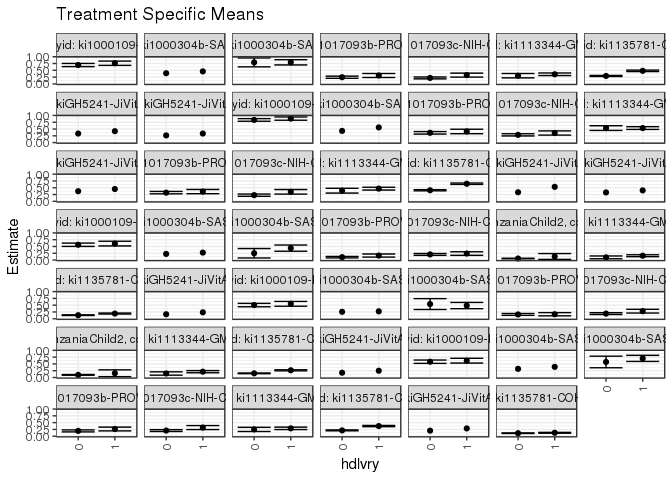

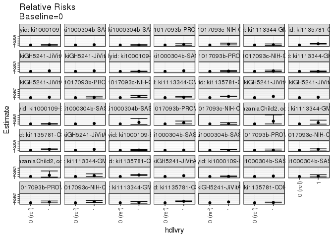

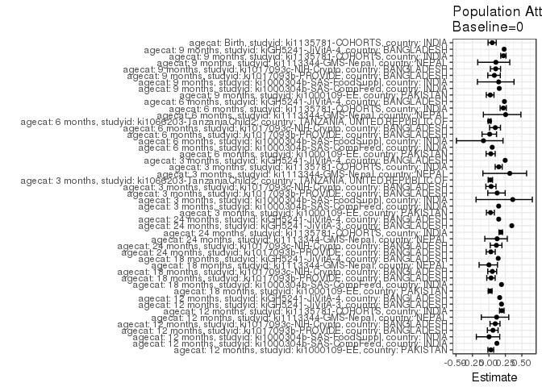

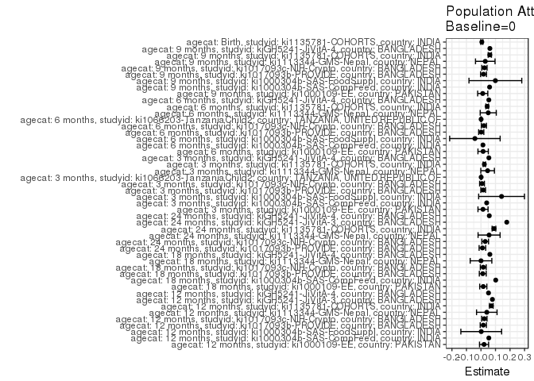

## Results Table

### Parameter: TSM

| agecat | studyid | country | intervention_level | baseline_level | estimate | ci_lower | ci_upper |
| --- | --- | --- | --- | --- | --- | --- | --- |
| Birth | ki1135781-COHORTS | INDIA | 0 | NA | 0.1106195 | 0.0992765 | 0.1219625 |
| Birth | ki1135781-COHORTS | INDIA | 1 | NA | 0.1264237 | 0.1108785 | 0.1419689 |
| 3 months | ki1000109-EE | PAKISTAN | 0 | NA | 0.5634921 | 0.5021767 | 0.6248074 |
| 3 months | ki1000109-EE | PAKISTAN | 1 | NA | 0.6065574 | 0.5197561 | 0.6933587 |
| 3 months | ki1000304b-SAS-CompFeed | INDIA | 0 | NA | 0.2253521 | NA | NA |
| 3 months | ki1000304b-SAS-CompFeed | INDIA | 1 | NA | 0.2743056 | NA | NA |
| 3 months | ki1000304b-SAS-FoodSuppl | INDIA | 0 | NA | 0.2500000 | 0.0758621 | 0.4241379 |
| 3 months | ki1000304b-SAS-FoodSuppl | INDIA | 1 | NA | 0.4383562 | 0.3239417 | 0.5527706 |
| 3 months | ki1017093b-PROVIDE | BANGLADESH | 0 | NA | 0.1058091 | 0.0783278 | 0.1332905 |
| 3 months | ki1017093b-PROVIDE | BANGLADESH | 1 | NA | 0.1656442 | 0.1085285 | 0.2227598 |
| 3 months | ki1017093c-NIH-Crypto | BANGLADESH | 0 | NA | 0.2070796 | 0.1736443 | 0.2405150 |
| 3 months | ki1017093c-NIH-Crypto | BANGLADESH | 1 | NA | 0.2392638 | 0.1737235 | 0.3048041 |
| 3 months | ki1066203-TanzaniaChild2 | TANZANIA, UNITED REPUBLIC OF | 0 | NA | 0.0566479 | 0.0468423 | 0.0664536 |
| 3 months | ki1066203-TanzaniaChild2 | TANZANIA, UNITED REPUBLIC OF | 1 | NA | 0.1315789 | 0.0240774 | 0.2390805 |
| 3 months | ki1113344-GMS-Nepal | NEPAL | 0 | NA | 0.0984849 | 0.0476058 | 0.1493639 |
| 3 months | ki1113344-GMS-Nepal | NEPAL | 1 | NA | 0.1592040 | 0.1234055 | 0.1950024 |
| 3 months | ki1135781-COHORTS | INDIA | 0 | NA | 0.1314554 | 0.1193264 | 0.1435844 |
| 3 months | ki1135781-COHORTS | INDIA | 1 | NA | 0.1918542 | 0.1739866 | 0.2097219 |
| 3 months | kiGH5241-JiVitA-4 | BANGLADESH | 0 | NA | 0.1658537 | NA | NA |
| 3 months | kiGH5241-JiVitA-4 | BANGLADESH | 1 | NA | 0.2375776 | NA | NA |
| 6 months | ki1000109-EE | PAKISTAN | 0 | NA | 0.5040323 | 0.4417211 | 0.5663434 |
| 6 months | ki1000109-EE | PAKISTAN | 1 | NA | 0.5491803 | 0.4607676 | 0.6375931 |
| 6 months | ki1000304b-SAS-CompFeed | INDIA | 0 | NA | 0.2567568 | NA | NA |
| 6 months | ki1000304b-SAS-CompFeed | INDIA | 1 | NA | 0.2740214 | NA | NA |
| 6 months | ki1000304b-SAS-FoodSuppl | INDIA | 0 | NA | 0.5416667 | 0.3412780 | 0.7420553 |
| 6 months | ki1000304b-SAS-FoodSuppl | INDIA | 1 | NA | 0.4861111 | 0.3700577 | 0.6021646 |
| 6 months | ki1017093b-PROVIDE | BANGLADESH | 0 | NA | 0.1593533 | 0.1248498 | 0.1938569 |
| 6 months | ki1017093b-PROVIDE | BANGLADESH | 1 | NA | 0.1666667 | 0.1069756 | 0.2263577 |
| 6 months | ki1017093c-NIH-Crypto | BANGLADESH | 0 | NA | 0.1895307 | 0.1568715 | 0.2221899 |
| 6 months | ki1017093c-NIH-Crypto | BANGLADESH | 1 | NA | 0.2795031 | 0.2101368 | 0.3488694 |

[output cut: 66 more lines]

### Parameter: E(Y)

| agecat | studyid | country | intervention_level | baseline_level | estimate | ci_lower | ci_upper |
| --- | --- | --- | --- | --- | --- | --- | --- |
| Birth | ki1135781-COHORTS | INDIA | NA | NA | 0.1165317 | 0.1073518 | 0.1257117 |
| 3 months | ki1000109-EE | PAKISTAN | NA | NA | 0.5775401 | 0.5274124 | 0.6276678 |
| 3 months | ki1000304b-SAS-CompFeed | INDIA | NA | NA | 0.2646240 | NA | NA |
| 3 months | ki1000304b-SAS-FoodSuppl | INDIA | NA | NA | 0.3917526 | 0.2941057 | 0.4893995 |
| 3 months | ki1017093b-PROVIDE | BANGLADESH | NA | NA | 0.1209302 | 0.0957486 | 0.1461119 |
| 3 months | ki1017093c-NIH-Crypto | BANGLADESH | NA | NA | 0.2142857 | 0.1844587 | 0.2441127 |
| 3 months | ki1066203-TanzaniaChild2 | TANZANIA, UNITED REPUBLIC OF | NA | NA | 0.0579577 | 0.0481332 | 0.0677821 |
| 3 months | ki1113344-GMS-Nepal | NEPAL | NA | NA | 0.1441948 | 0.1143721 | 0.1740174 |
| 3 months | ki1135781-COHORTS | INDIA | NA | NA | 0.1547030 | 0.1445226 | 0.1648834 |
| 3 months | kiGH5241-JiVitA-4 | BANGLADESH | NA | NA | 0.2202591 | NA | NA |
| 6 months | ki1000109-EE | PAKISTAN | NA | NA | 0.5189189 | 0.4679396 | 0.5698982 |
| 6 months | ki1000304b-SAS-CompFeed | INDIA | NA | NA | 0.2704225 | NA | NA |
| 6 months | ki1000304b-SAS-FoodSuppl | INDIA | NA | NA | 0.5000000 | 0.3994560 | 0.6005440 |
| 6 months | ki1017093b-PROVIDE | BANGLADESH | NA | NA | 0.1612350 | 0.1313580 | 0.1911120 |
| 6 months | ki1017093c-NIH-Crypto | BANGLADESH | NA | NA | 0.2097902 | 0.1799252 | 0.2396552 |
| 6 months | ki1066203-TanzaniaChild2 | TANZANIA, UNITED REPUBLIC OF | NA | NA | 0.0973451 | 0.0840860 | 0.1106043 |
| 6 months | ki1113344-GMS-Nepal | NEPAL | NA | NA | 0.1973435 | 0.1633315 | 0.2313554 |
| 6 months | ki1135781-COHORTS | INDIA | NA | NA | 0.1955735 | 0.1842315 | 0.2069155 |
| 6 months | kiGH5241-JiVitA-4 | BANGLADESH | NA | NA | 0.2301815 | NA | NA |
| 9 months | ki1000109-EE | PAKISTAN | NA | NA | 0.5934066 | 0.5428764 | 0.6439368 |
| 9 months | ki1000304b-SAS-CompFeed | INDIA | NA | NA | 0.3775216 | NA | NA |
| 9 months | ki1000304b-SAS-FoodSuppl | INDIA | NA | NA | 0.6705882 | 0.5700790 | 0.7710975 |
| 9 months | ki1017093b-PROVIDE | BANGLADESH | NA | NA | 0.2132231 | 0.1805589 | 0.2458874 |
| 9 months | ki1017093c-NIH-Crypto | BANGLADESH | NA | NA | 0.2322946 | 0.2011222 | 0.2634670 |
| 9 months | ki1113344-GMS-Nepal | NEPAL | NA | NA | 0.2796117 | 0.2408120 | 0.3184113 |
| 9 months | ki1135781-COHORTS | INDIA | NA | NA | 0.2756598 | 0.2619671 | 0.2893526 |
| 9 months | kiGH5241-JiVitA-4 | BANGLADESH | NA | NA | 0.2650376 | NA | NA |
| 12 months | ki1000109-EE | PAKISTAN | NA | NA | 0.7154930 | 0.6684932 | 0.7624927 |
| 12 months | ki1000304b-SAS-CompFeed | INDIA | NA | NA | 0.4459834 | NA | NA |
| 12 months | ki1000304b-SAS-FoodSuppl | INDIA | NA | NA | 0.7934783 | 0.7103061 | 0.8766504 |
| 12 months | ki1017093b-PROVIDE | BANGLADESH | NA | NA | 0.2616667 | 0.2264673 | 0.2968661 |
| 12 months | ki1017093c-NIH-Crypto | BANGLADESH | NA | NA | 0.2422096 | 0.2105851 | 0.2738341 |
| 12 months | ki1113344-GMS-Nepal | NEPAL | NA | NA | 0.3416507 | 0.3008877 | 0.3824136 |
| 12 months | ki1135781-COHORTS | INDIA | NA | NA | 0.3632373 | 0.3476223 | 0.3788523 |
| 12 months | kiGH5241-JiVitA-3 | BANGLADESH | NA | NA | 0.4121622 | NA | NA |
| 12 months | kiGH5241-JiVitA-4 | BANGLADESH | NA | NA | 0.3170732 | NA | NA |
| 18 months | ki1000109-EE | PAKISTAN | NA | NA | 0.8505747 | 0.8130643 | 0.8880851 |
| 18 months | ki1000304b-SAS-CompFeed | INDIA | NA | NA | 0.5321637 | NA | NA |
| 18 months | ki1017093b-PROVIDE | BANGLADESH | NA | NA | 0.3731884 | 0.3328048 | 0.4135720 |
| 18 months | ki1017093c-NIH-Crypto | BANGLADESH | NA | NA | 0.3012618 | 0.2655201 | 0.3370036 |
| 18 months | ki1113344-GMS-Nepal | NEPAL | NA | NA | 0.5351562 | 0.4919117 | 0.5784008 |
| 18 months | kiGH5241-JiVitA-4 | BANGLADESH | NA | NA | 0.4337812 | NA | NA |
| 24 months | ki1017093b-PROVIDE | BANGLADESH | NA | NA | 0.3292894 | 0.2909105 | 0.3676684 |
| 24 months | ki1017093c-NIH-Crypto | BANGLADESH | NA | NA | 0.2568093 | 0.2190047 | 0.2946140 |
| 24 months | ki1113344-GMS-Nepal | NEPAL | NA | NA | 0.4475375 | 0.4023913 | 0.4926837 |
| 24 months | ki1135781-COHORTS | INDIA | NA | NA | 0.4964878 | 0.4800590 | 0.5129165 |
| 24 months | kiGH5241-JiVitA-3 | BANGLADESH | NA | NA | 0.5109489 | NA | NA |
| 24 months | kiGH5241-JiVitA-4 | BANGLADESH | NA | NA | 0.3841060 | NA | NA |

### Parameter: RR

| agecat | studyid | country | intervention_level | baseline_level | estimate | ci_lower | ci_upper |
| --- | --- | --- | --- | --- | --- | --- | --- |
| Birth | ki1135781-COHORTS | INDIA | 0 | 0 | 1.0000000 | 1.0000000 | 1.000000 |
| Birth | ki1135781-COHORTS | INDIA | 1 | 0 | 1.1428702 | 0.9737860 | 1.341313 |
| 3 months | ki1000109-EE | PAKISTAN | 0 | 0 | 1.0000000 | 1.0000000 | 1.000000 |
| 3 months | ki1000109-EE | PAKISTAN | 1 | 0 | 1.0764258 | 0.8993081 | 1.288427 |
| 3 months | ki1000304b-SAS-CompFeed | INDIA | 0 | 0 | 1.0000000 | NA | NA |
| 3 months | ki1000304b-SAS-CompFeed | INDIA | 1 | 0 | 1.2172309 | NA | NA |
| 3 months | ki1000304b-SAS-FoodSuppl | INDIA | 0 | 0 | 1.0000000 | 1.0000000 | 1.000000 |
| 3 months | ki1000304b-SAS-FoodSuppl | INDIA | 1 | 0 | 1.7534247 | 0.8333705 | 3.689233 |
| 3 months | ki1017093b-PROVIDE | BANGLADESH | 0 | 0 | 1.0000000 | 1.0000000 | 1.000000 |
| 3 months | ki1017093b-PROVIDE | BANGLADESH | 1 | 0 | 1.5654998 | 1.0166587 | 2.410632 |
| 3 months | ki1017093c-NIH-Crypto | BANGLADESH | 0 | 0 | 1.0000000 | 1.0000000 | 1.000000 |
| 3 months | ki1017093c-NIH-Crypto | BANGLADESH | 1 | 0 | 1.1554192 | 0.8407120 | 1.587932 |
| 3 months | ki1066203-TanzaniaChild2 | TANZANIA, UNITED REPUBLIC OF | 0 | 0 | 1.0000000 | 1.0000000 | 1.000000 |
| 3 months | ki1066203-TanzaniaChild2 | TANZANIA, UNITED REPUBLIC OF | 1 | 0 | 2.3227490 | 1.0076333 | 5.354292 |
| 3 months | ki1113344-GMS-Nepal | NEPAL | 0 | 0 | 1.0000000 | 1.0000000 | 1.000000 |
| 3 months | ki1113344-GMS-Nepal | NEPAL | 1 | 0 | 1.6165327 | 0.9202140 | 2.839750 |
| 3 months | ki1135781-COHORTS | INDIA | 0 | 0 | 1.0000000 | 1.0000000 | 1.000000 |
| 3 months | ki1135781-COHORTS | INDIA | 1 | 0 | 1.4594626 | 1.2801413 | 1.663903 |
| 3 months | kiGH5241-JiVitA-4 | BANGLADESH | 0 | 0 | 1.0000000 | NA | NA |
| 3 months | kiGH5241-JiVitA-4 | BANGLADESH | 1 | 0 | 1.4324534 | NA | NA |
| 6 months | ki1000109-EE | PAKISTAN | 0 | 0 | 1.0000000 | 1.0000000 | 1.000000 |
| 6 months | ki1000109-EE | PAKISTAN | 1 | 0 | 1.0895738 | 0.8894126 | 1.334781 |
| 6 months | ki1000304b-SAS-CompFeed | INDIA | 0 | 0 | 1.0000000 | NA | NA |
| 6 months | ki1000304b-SAS-CompFeed | INDIA | 1 | 0 | 1.0672411 | NA | NA |
| 6 months | ki1000304b-SAS-FoodSuppl | INDIA | 0 | 0 | 1.0000000 | 1.0000000 | 1.000000 |
| 6 months | ki1000304b-SAS-FoodSuppl | INDIA | 1 | 0 | 0.8974359 | 0.5778122 | 1.393863 |
| 6 months | ki1017093b-PROVIDE | BANGLADESH | 0 | 0 | 1.0000000 | 1.0000000 | 1.000000 |
| 6 months | ki1017093b-PROVIDE | BANGLADESH | 1 | 0 | 1.0458937 | 0.6882258 | 1.589440 |
| 6 months | ki1017093c-NIH-Crypto | BANGLADESH | 0 | 0 | 1.0000000 | 1.0000000 | 1.000000 |
| 6 months | ki1017093c-NIH-Crypto | BANGLADESH | 1 | 0 | 1.4747116 | 1.0901648 | 1.994904 |

[output cut: 66 more lines]

### Parameter: PAR

| agecat | studyid | country | intervention_level | baseline_level | estimate | ci_lower | ci_upper |
| --- | --- | --- | --- | --- | --- | --- | --- |
| Birth | ki1135781-COHORTS | INDIA | 0 | NA | 0.0059123 | -0.0012900 | 0.0131145 |
| 3 months | ki1000109-EE | PAKISTAN | 0 | NA | 0.0140480 | -0.0206792 | 0.0487753 |
| 3 months | ki1000304b-SAS-CompFeed | INDIA | 0 | NA | 0.0392718 | NA | NA |
| 3 months | ki1000304b-SAS-FoodSuppl | INDIA | 0 | NA | 0.1417526 | -0.0158965 | 0.2994017 |
| 3 months | ki1017093b-PROVIDE | BANGLADESH | 0 | NA | 0.0151211 | -0.0010220 | 0.0312643 |
| 3 months | ki1017093c-NIH-Crypto | BANGLADESH | 0 | NA | 0.0072061 | -0.0092966 | 0.0237087 |
| 3 months | ki1066203-TanzaniaChild2 | TANZANIA, UNITED REPUBLIC OF | 0 | NA | 0.0013097 | -0.0006218 | 0.0032412 |
| 3 months | ki1113344-GMS-Nepal | NEPAL | 0 | NA | 0.0457099 | -0.0011759 | 0.0925957 |
| 3 months | ki1135781-COHORTS | INDIA | 0 | NA | 0.0232476 | 0.0148944 | 0.0316008 |
| 3 months | kiGH5241-JiVitA-4 | BANGLADESH | 0 | NA | 0.0544055 | NA | NA |
| 6 months | ki1000109-EE | PAKISTAN | 0 | NA | 0.0148867 | -0.0208440 | 0.0506173 |
| 6 months | ki1000304b-SAS-CompFeed | INDIA | 0 | NA | 0.0136658 | NA | NA |
| 6 months | ki1000304b-SAS-FoodSuppl | INDIA | 0 | NA | -0.0416667 | -0.2154105 | 0.1320771 |
| 6 months | ki1017093b-PROVIDE | BANGLADESH | 0 | NA | 0.0018816 | -0.0158593 | 0.0196226 |
| 6 months | ki1017093c-NIH-Crypto | BANGLADESH | 0 | NA | 0.0202595 | 0.0027767 | 0.0377424 |
| 6 months | ki1066203-TanzaniaChild2 | TANZANIA, UNITED REPUBLIC OF | 0 | NA | 0.0009979 | -0.0011377 | 0.0031334 |
| 6 months | ki1113344-GMS-Nepal | NEPAL | 0 | NA | 0.0500566 | -0.0053463 | 0.1054595 |
| 6 months | ki1135781-COHORTS | INDIA | 0 | NA | 0.0428149 | 0.0334094 | 0.0522204 |
| 6 months | kiGH5241-JiVitA-4 | BANGLADESH | 0 | NA | 0.0541515 | NA | NA |
| 9 months | ki1000109-EE | PAKISTAN | 0 | NA | 0.0121058 | -0.0227239 | 0.0469355 |
| 9 months | ki1000304b-SAS-CompFeed | INDIA | 0 | NA | 0.0593398 | NA | NA |
| 9 months | ki1000304b-SAS-FoodSuppl | INDIA | 0 | NA | 0.0991597 | -0.0825946 | 0.2809139 |
| 9 months | ki1017093b-PROVIDE | BANGLADESH | 0 | NA | 0.0176676 | -0.0026069 | 0.0379421 |
| 9 months | ki1017093c-NIH-Crypto | BANGLADESH | 0 | NA | 0.0239613 | 0.0059681 | 0.0419544 |
| 9 months | ki1113344-GMS-Nepal | NEPAL | 0 | NA | 0.0296117 | -0.0376397 | 0.0968630 |
| 9 months | ki1135781-COHORTS | INDIA | 0 | NA | 0.0608921 | 0.0495774 | 0.0722067 |
| 9 months | kiGH5241-JiVitA-4 | BANGLADESH | 0 | NA | 0.0613339 | NA | NA |
| 12 months | ki1000109-EE | PAKISTAN | 0 | NA | 0.0212781 | -0.0100434 | 0.0525996 |
| 12 months | ki1000304b-SAS-CompFeed | INDIA | 0 | NA | 0.0540915 | NA | NA |
| 12 months | ki1000304b-SAS-FoodSuppl | INDIA | 0 | NA | 0.0018116 | -0.1384806 | 0.1421038 |
| 12 months | ki1017093b-PROVIDE | BANGLADESH | 0 | NA | 0.0161310 | -0.0051777 | 0.0374396 |
| 12 months | ki1017093c-NIH-Crypto | BANGLADESH | 0 | NA | 0.0232315 | 0.0048769 | 0.0415862 |
| 12 months | ki1113344-GMS-Nepal | NEPAL | 0 | NA | 0.0400634 | -0.0305314 | 0.1106581 |
| 12 months | ki1135781-COHORTS | INDIA | 0 | NA | 0.0713502 | 0.0587712 | 0.0839291 |
| 12 months | kiGH5241-JiVitA-3 | BANGLADESH | 0 | NA | 0.0788288 | NA | NA |
| 12 months | kiGH5241-JiVitA-4 | BANGLADESH | 0 | NA | 0.0519217 | NA | NA |
| 18 months | ki1000109-EE | PAKISTAN | 0 | NA | 0.0158289 | -0.0087606 | 0.0404185 |
| 18 months | ki1000304b-SAS-CompFeed | INDIA | 0 | NA | 0.1016082 | NA | NA |
| 18 months | ki1017093b-PROVIDE | BANGLADESH | 0 | NA | 0.0124136 | -0.0113383 | 0.0361655 |
| 18 months | ki1017093c-NIH-Crypto | BANGLADESH | 0 | NA | 0.0158409 | -0.0044899 | 0.0361717 |
| 18 months | ki1113344-GMS-Nepal | NEPAL | 0 | NA | 0.0002725 | -0.0742430 | 0.0747881 |
| 18 months | kiGH5241-JiVitA-4 | BANGLADESH | 0 | NA | 0.0612322 | NA | NA |
| 24 months | ki1017093b-PROVIDE | BANGLADESH | 0 | NA | 0.0098450 | -0.0127319 | 0.0324218 |
| 24 months | ki1017093c-NIH-Crypto | BANGLADESH | 0 | NA | 0.0291879 | 0.0062351 | 0.0521406 |
| 24 months | ki1113344-GMS-Nepal | NEPAL | 0 | NA | 0.0558708 | -0.0199820 | 0.1317236 |
| 24 months | ki1135781-COHORTS | INDIA | 0 | NA | 0.0894121 | 0.0766037 | 0.1022205 |
| 24 months | kiGH5241-JiVitA-3 | BANGLADESH | 0 | NA | 0.1776156 | NA | NA |
| 24 months | kiGH5241-JiVitA-4 | BANGLADESH | 0 | NA | 0.0572577 | NA | NA |

### Parameter: PAF

| agecat | studyid | country | intervention_level | baseline_level | estimate | ci_lower | ci_upper |
| --- | --- | --- | --- | --- | --- | --- | --- |
| Birth | ki1135781-COHORTS | INDIA | 0 | NA | 0.0507353 | -0.0130228 | 0.1104806 |
| 3 months | ki1000109-EE | PAKISTAN | 0 | NA | 0.0243239 | -0.0377628 | 0.0826962 |
| 3 months | ki1000304b-SAS-CompFeed | INDIA | 0 | NA | 0.1484062 | NA | NA |
| 3 months | ki1000304b-SAS-FoodSuppl | INDIA | 0 | NA | 0.3618421 | -0.1955447 | 0.6593641 |
| 3 months | ki1017093b-PROVIDE | BANGLADESH | 0 | NA | 0.1250399 | -0.0169134 | 0.2471776 |
| 3 months | ki1017093c-NIH-Crypto | BANGLADESH | 0 | NA | 0.0336283 | -0.0464629 | 0.1075897 |
| 3 months | ki1066203-TanzaniaChild2 | TANZANIA, UNITED REPUBLIC OF | 0 | NA | 0.0225982 | -0.0111014 | 0.0551747 |
| 3 months | ki1113344-GMS-Nepal | NEPAL | 0 | NA | 0.3170012 | -0.0912232 | 0.5725097 |
| 3 months | ki1135781-COHORTS | INDIA | 0 | NA | 0.1502723 | 0.0951932 | 0.2019985 |
| 3 months | kiGH5241-JiVitA-4 | BANGLADESH | 0 | NA | 0.2470067 | NA | NA |
| 6 months | ki1000109-EE | PAKISTAN | 0 | NA | 0.0286878 | -0.0427352 | 0.0952187 |
| 6 months | ki1000304b-SAS-CompFeed | INDIA | 0 | NA | 0.0505349 | NA | NA |
| 6 months | ki1000304b-SAS-FoodSuppl | INDIA | 0 | NA | -0.0833333 | -0.4936687 | 0.2142762 |
| 6 months | ki1017093b-PROVIDE | BANGLADESH | 0 | NA | 0.0116702 | -0.1047054 | 0.1157862 |
| 6 months | ki1017093c-NIH-Crypto | BANGLADESH | 0 | NA | 0.0965704 | 0.0099200 | 0.1756373 |
| 6 months | ki1066203-TanzaniaChild2 | TANZANIA, UNITED REPUBLIC OF | 0 | NA | 0.0102507 | -0.0118966 | 0.0319133 |
| 6 months | ki1113344-GMS-Nepal | NEPAL | 0 | NA | 0.2536524 | -0.0840400 | 0.4861492 |
| 6 months | ki1135781-COHORTS | INDIA | 0 | NA | 0.2189197 | 0.1704333 | 0.2645722 |
| 6 months | kiGH5241-JiVitA-4 | BANGLADESH | 0 | NA | 0.2352557 | NA | NA |
| 9 months | ki1000109-EE | PAKISTAN | 0 | NA | 0.0204005 | -0.0401388 | 0.0774162 |
| 9 months | ki1000304b-SAS-CompFeed | INDIA | 0 | NA | 0.1571825 | NA | NA |
| 9 months | ki1000304b-SAS-FoodSuppl | INDIA | 0 | NA | 0.1478697 | -0.1742965 | 0.3816501 |
| 9 months | ki1017093b-PROVIDE | BANGLADESH | 0 | NA | 0.0828596 | -0.0168568 | 0.1727974 |
| 9 months | ki1017093c-NIH-Crypto | BANGLADESH | 0 | NA | 0.1031504 | 0.0228674 | 0.1768372 |
| 9 months | ki1113344-GMS-Nepal | NEPAL | 0 | NA | 0.1059028 | -0.1698916 | 0.3166804 |
| 9 months | ki1135781-COHORTS | INDIA | 0 | NA | 0.2208957 | 0.1793830 | 0.2603084 |
| 9 months | kiGH5241-JiVitA-4 | BANGLADESH | 0 | NA | 0.2314158 | NA | NA |
| 12 months | ki1000109-EE | PAKISTAN | 0 | NA | 0.0297391 | -0.0152162 | 0.0727036 |
| 12 months | ki1000304b-SAS-CompFeed | INDIA | 0 | NA | 0.1212859 | NA | NA |
| 12 months | ki1000304b-SAS-FoodSuppl | INDIA | 0 | NA | 0.0022831 | -0.1911588 | 0.1643104 |
| 12 months | ki1017093b-PROVIDE | BANGLADESH | 0 | NA | 0.0616470 | -0.0232710 | 0.1395178 |
| 12 months | ki1017093c-NIH-Crypto | BANGLADESH | 0 | NA | 0.0959150 | 0.0173446 | 0.1682031 |
| 12 months | ki1113344-GMS-Nepal | NEPAL | 0 | NA | 0.1172641 | -0.1155004 | 0.3014592 |
| 12 months | ki1135781-COHORTS | INDIA | 0 | NA | 0.1964286 | 0.1611310 | 0.2302409 |
| 12 months | kiGH5241-JiVitA-3 | BANGLADESH | 0 | NA | 0.1912568 | NA | NA |
| 12 months | kiGH5241-JiVitA-4 | BANGLADESH | 0 | NA | 0.1637529 | NA | NA |
| 18 months | ki1000109-EE | PAKISTAN | 0 | NA | 0.0186097 | -0.0108514 | 0.0472122 |
| 18 months | ki1000304b-SAS-CompFeed | INDIA | 0 | NA | 0.1909341 | NA | NA |
| 18 months | ki1017093b-PROVIDE | BANGLADESH | 0 | NA | 0.0332636 | -0.0325405 | 0.0948739 |
| 18 months | ki1017093c-NIH-Crypto | BANGLADESH | 0 | NA | 0.0525818 | -0.0173087 | 0.1176707 |
| 18 months | ki1113344-GMS-Nepal | NEPAL | 0 | NA | 0.0005093 | -0.1488970 | 0.1304862 |
| 18 months | kiGH5241-JiVitA-4 | BANGLADESH | 0 | NA | 0.1411591 | NA | NA |
| 24 months | ki1017093b-PROVIDE | BANGLADESH | 0 | NA | 0.0298977 | -0.0411411 | 0.0960893 |
| 24 months | ki1017093c-NIH-Crypto | BANGLADESH | 0 | NA | 0.1136557 | 0.0202907 | 0.1981232 |
| 24 months | ki1113344-GMS-Nepal | NEPAL | 0 | NA | 0.1248405 | -0.0624110 | 0.2790886 |
| 24 months | ki1135781-COHORTS | INDIA | 0 | NA | 0.1800892 | 0.1534463 | 0.2058937 |
| 24 months | kiGH5241-JiVitA-3 | BANGLADESH | 0 | NA | 0.3476190 | NA | NA |
| 24 months | kiGH5241-JiVitA-4 | BANGLADESH | 0 | NA | 0.1490675 | NA | NA |